# Краткое введение в мир матричной алгебры

## Вы сможете

- Объяснить что такое матрицы и какие бывают их основные разновидности
- Выполнить базовые операции с матрицами с использованием функций R
- Применить в среде R методы матричной алгебры для решения простейших задач

## Решите задачу

В популяции некоторого организма в момент времени \(t_1\) представлено четыре возрастные группы:

| Возрастная группа | Количество особей |
| --- | --- |
| 0+ | 100 |
| 1+ | 10 |
| 2+ | 5 |
| 3+ | 1 |

Какова будет численность возрастных групп в момент времени \(t_2\) если известно, что

1. каждая особь возрастом 2+ оставляет 10 потомков, а каждая особь возрастом 3+ - 20 потомков.
2. вероятность выживания особей при переходе от \(t_1\) к \(t_2\) описывается следующими величинами

| Переход из младшей группы в старшую | Вероятность выживания |
| --- | --- |
| 0+ - 1+ | 0.1 |
| 1+ - 2+ | 0.5 |
| 2+ - 3+ | 0.3 |

## Простое, но нерациональное решение

| Возрастная группа | Количество особей в момент времени \(t_2\) |
| --- | --- |
| 0+ | \(5 \cdot 10 + 1 \cdot 20 = 70\) |
| 1+ | \(100 \cdot 0.1 = 10\) |
| 2+ | \(10 \cdot 0.5 = 5\) |
| 3+ | \(5 \cdot 0.3 = 1.5\) |

## Рациональное решение

Демографический вектор в момент времени \(t_1\)

```r
t1 <- c(100, 10, 5, 1)
t1
```

```
## [1] 100  10   5   1
```

## Рациональное решение

Демографическая матрица Лесли

\[ \begin{pmatrix} F_1 & F_2 & F_3 & F_4 \\ P_{0+ -1+}& 0 & 0 & 0 \\ 0 & P_{1+-2+} & 0 & 0 \\ 0 & 0 & P_{2+-3+} & 0 \\ \end{pmatrix} \]

```r
lesley <- matrix(c(c(0, 0, 10, 20), c(0.1, 0, 0, 0), c(0, 0.5, 0, 0), c(0, 0, 0.3, 0)), nrow = 4, byrow = T)

lesley
```

```
##      [,1] [,2] [,3] [,4]
## [1,]  0.0  0.0 10.0   20
## [2,]  0.1  0.0  0.0    0
## [3,]  0.0  0.5  0.0    0
## [4,]  0.0  0.0  0.3    0
```

```r
lesley %*% t1
```

```
##      [,1]
## [1,] 70.0
## [2,] 10.0
## [3,]  5.0
## [4,]  1.5
```

## Зачем нужны матрицы?

## Матричные объекты

- Есть много типов объектов, для которых такое выражение оказывается наиболее естественным (изображения, описания многомерных объектов и т.д.)
- В матрицах, как и в обычных числах, скрыта информация, которую можно извлекать и преобразовывать по определенным правилам

## Структура матриц

\[\begin{pmatrix} a_{11} & a_{12} & \cdots & a_{1c} \\ a_{21} & a_{22} & \cdots & a_{2c} \\ \vdots & \vdots & \ddots & \vdots \\ a_{r1} & a_{r2} & \cdots & a_{rc} \end{pmatrix} \]

Размер (порядок) матрицы \(r \times c\)

## Разновидности матриц

Вектор-строка (row matrix)

\[ \textbf {A} = \begin{pmatrix} 1 & 2 & 3 \end{pmatrix} \]

Вектор-столбец (column matrix)

\[ \textbf {B} = \begin{pmatrix} 1 \\ 4 \\ 7 \\ 10 \end{pmatrix} \]

## Разновидности матриц

Прямоугольные матрицы (rectangular matrices)

\[ \textbf {C} = \begin{pmatrix} 1 & 2 & 3 \\ 4 & 5 & 6 \\ 7 & 8 & 9 \\ 10 & 11 & 12 \end{pmatrix} \]

\[ \textbf {D} = \begin{pmatrix} 1 & 2 & 3 \\ 4 & 5 & 6 \end{pmatrix} \]

В таком виде обычно представляются исходные данные

## Квадратные матрицы (square matrices)

Это наиболее "операбельные" матрицы

\[ \textbf {E} = \begin{pmatrix} 1 & 2 & 3 \\ 4 & 5 & 6 \\ 7 & 8 & 9 \end{pmatrix} \]

Диагональные матрицы (diagonal matrix)

\[ \textbf {F} = \begin{pmatrix} 1 & 0 & 0 & 0 \\ 0 & 5 & 0 & 0 \\ 0 & 0 & 9 & 0 \\ 0 & 0 & 0 & 1 \end{pmatrix} \]

## Квадратные матрицы (square matrices)

Единичная матрица (identity matrix) \[ \textbf {I} = \begin{pmatrix} 1 & 0 & 0 & 0 \\ 0 & 1 & 0 & 0 \\ 0 & 0 & 1 & 0 \\ 0 & 0 & 0 & 1 \end{pmatrix} \]

Единичная матрица (обозначение \(\textbf{I}\)) занимают особое место в матричной алгебре.  
Она выполняет ту же роль, которую выполняет единица в обычной алгебре.

## Особенность квадратных матриц

Для квадратных матриц могут быть найдены (но не обязательно существуют) некоторые важные для матричной алгебры показатели: *определитель*, *инверсия*, *собственные значения* и *собственные векторы*

## Задание

Создайте с помощью R следующую матрицу

```
##      [,1] [,2] [,3]
## [1,]    1    2    3
## [2,]    4    5    6
## [3,]    7    8    9
## [4,]   10   11   12
```

## Задание

Создайте с помощью R единичную матрицу

## Решение

```
##      [,1] [,2] [,3] [,4] [,5]
## [1,]    1    0    0    0    0
## [2,]    0    1    0    0    0
## [3,]    0    0    1    0    0
## [4,]    0    0    0    1    0
## [5,]    0    0    0    0    1
```

## Операции с матрицами

## Транспонирование матриц

```r
A <- matrix(1:12, ncol = 3)
A
```

```
##      [,1] [,2] [,3]
## [1,]    1    5    9
## [2,]    2    6   10
## [3,]    3    7   11
## [4,]    4    8   12
```

Транспонированная матрица \(\textbf{A}\)

```r
B <- t(A)
B
```

```
##      [,1] [,2] [,3] [,4]
## [1,]    1    2    3    4
## [2,]    5    6    7    8
## [3,]    9   10   11   12
```

## Сложение матриц

```r
A + 4
```

```
##      [,1] [,2] [,3]
## [1,]    5    9   13
## [2,]    6   10   14
## [3,]    7   11   15
## [4,]    8   12   16
```

```r
A + A
```

```
##      [,1] [,2] [,3]
## [1,]    2   10   18
## [2,]    4   12   20
## [3,]    6   14   22
## [4,]    8   16   24
```

Но! Нельзя складывать матрицы разных размеров

```r
A + B
```

## Биологическое приложение

Предположим, что мы подсчитывали двумя разными методами крупных и мелких животных трех видов в одних и тех же пробах

```
##         Sp1 Sp2 Sp3
## Sample1  11   8  14
## Sample2  14  12   9
## Sample3  10  10   9
## Sample4  10   9  10
## Sample5  12  10  10
```

```
##         Sp1 Sp2 Sp3
## Sample1  45  51  48
## Sample2  54  41  50
## Sample3  52  48  44
## Sample4  43  52  50
## Sample5  47  55  54
```

## Биологическое приложение

Общее обилие

```r
Large + Small
```

```
##         Sp1 Sp2 Sp3
## Sample1  56  59  62
## Sample2  68  53  59
## Sample3  62  58  53
## Sample4  53  61  60
## Sample5  59  65  64
```

## Простое умножение

Умножение на число

```r
A * 4
```

```
##      [,1] [,2] [,3]
## [1,]    4   20   36
## [2,]    8   24   40
## [3,]   12   28   44
## [4,]   16   32   48
```

Простое умножение матрицы на вектор возможно только если число элементов в векторе равно числу строк в матрице

```r
A * c(10, 11, 12, 13)
```

```
##      [,1] [,2] [,3]
## [1,]   10   50   90
## [2,]   22   66  110
## [3,]   36   84  132
## [4,]   52  104  156
```

Все элементы первой строки матрицы умножаются на первый элемент вектора, все элементы второй строки на второй элемент вектора и т.д.

## Биологическое применение

Допустим, учет организмов в части описаний проходил не на всей выборке, а лишь в ее части.

```r
Rpocessed_portion <- c(1, 1, 1/2, 1/3, 1/4)
Processed_Factor <- 1/Rpocessed_portion
```

```r
Small * Processed_Factor
```

```
##         Sp1 Sp2 Sp3
## Sample1  45  51  48
## Sample2  54  41  50
## Sample3 104  96  88
## Sample4 129 156 150
## Sample5 188 220 216
```

## Скалярное произведение векторов

Допустимо только для векторов одинаковой размерности

\[ \textbf{a} \bullet \textbf{b} = \begin{pmatrix} a_1 \\ a_2 \\ a_3 \\ a_4 \\ a_5 \\ a_6 \\ a_7 \end{pmatrix} \times \begin{pmatrix} b_1 & b_2 & b_3 & b_4 & b_5 & b_6 & b_7 \end{pmatrix} = a_1 \cdot b_1 + a_2 \cdot b_2 + \ldots + a_7 \cdot b_7 = x \]

Результат этой операции - число (скаляр)

## Биологическое применение

Сколько особей родится в популяции, если мы знаем репродуктивные характеристики всех возрастных групп? \[ \begin{pmatrix} N_1 \\ N_2 \\ N_3 \\ N_4 \\ N_5 \\ N_6 \\ N_7 \end{pmatrix} \times \begin{pmatrix} F_1 & F_2 & F_3 & F_4 & F_5 & F_6 & F_7 \end{pmatrix} \]

```r
N <- c(20, 40, 32, 45, 80, 50, 10)
Fert <- c( 0,  0,   1,   2,   2,   0,   0)
t(N) %*% (Fert)
```

```
##      [,1]
## [1,]  282
```

## Умножение матриц

Умножать можно только в том случае, если число строк одной из матриц равно числу столбцов у другой матрицы.

```r
A
```

```
##      [,1] [,2] [,3]
## [1,]    1    5    9
## [2,]    2    6   10
## [3,]    3    7   11
## [4,]    4    8   12
```

```r
B
```

```
##      [,1] [,2] [,3] [,4]
## [1,]    1    2    3    4
## [2,]    5    6    7    8
## [3,]    9   10   11   12
```

```r
A %*% B
```

```
##      [,1] [,2] [,3] [,4]
## [1,]  107  122  137  152
## [2,]  122  140  158  176
## [3,]  137  158  179  200
## [4,]  152  176  200  224
```

У первой матрицы (`A`) число строк равно числу столбцов у второй матрцы (`B`)

## Умножение матриц

Порядок имеет смысл! Если поменять местами матрицы `A` и `B`, то изменится и результат

```r
B %*% A
```

```
##      [,1] [,2] [,3]
## [1,]   30   70  110
## [2,]   70  174  278
## [3,]  110  278  446
```

## Умножение матриц

Удалим из матрицы `B` последнюю строчку

```r
C <- B[-3, ]
C
```

```
##      [,1] [,2] [,3] [,4]
## [1,]    1    2    3    4
## [2,]    5    6    7    8
```

Такое произведение возможно

```r
C %*% A
```

```
##      [,1] [,2] [,3]
## [1,]   30   70  110
## [2,]   70  174  278
```

Но невозможно такое произведение

```r
A %*% C
```

## Умножение матриц

Если матрица ('A') не квадратная, то нельзя произвести такое умножение

```r
A %*% A
```

## Схема умножения матриц

\[ \begin{pmatrix} 1 & 2 & 3 \\ 4 & 5 & 6 \\ \end{pmatrix} \times \begin{pmatrix} 7 & 8 \\ 9 & 10\\ 11 & 12\\ \end{pmatrix} = \begin{pmatrix} 7 \cdot 1 + 9 \cdot 2 + 11 \cdot 3 & 8 \cdot 1 + 10 \cdot 2 + 12 \cdot 3 \\ 7 \cdot 4 + 9 \cdot 5 + 11 \cdot 6 & 8 \cdot 4 + 10 \cdot 5 + 12 \cdot 6 \\ \end{pmatrix} = \\ = \begin{pmatrix} 58 & 64 \\ 139 & 154\\ \end{pmatrix} \]

```r
M1 <- matrix(c(1, 2, 3, 4, 5, 6), byrow = T, ncol = 3)
M2 <-  matrix(7:12, byrow = T, ncol = 2)
M1 %*% M2
```

```
##      [,1] [,2]
## [1,]   58   64
## [2,]  139  154
```

## Биологическое применение

Простейший пример использования умножения матриц - построение модели динамики демографической структуры популяции Для вычислений необходим начальный *демографический вектор* и *матрица Лесли*

\[ \begin{pmatrix} F_1 & F_2 & F_3 & F_4 & F_5 & F_6 & F_7 \\ P_{1-2}& 0 & 0 & 0 & 0 & 0 & 0 \\ 0 & P_{2-3} & 0 & 0 & 0 & 0 & 0 \\ 0 & 0 & P_{3-4} & 0 & 0 & 0 & 0 \\ 0 & 0 & 0 & P_{4-5} & 0 & 0 & 0 \\ 0 & 0 & 0 & 0 & P_{5-6} & 0 & 0 \\ 0 & 0 & 0 & 0 & 0 & P_{6-7} & 0 \end{pmatrix} \times \begin{pmatrix} N1_t \\ N2_t \\ N3_t \\ N4_t \\ N5_t \\ N6_t \\ N7_t \end{pmatrix} = \begin{pmatrix} N1_{t+1} \\ N2_{t+1} \\ N3_{t+1} \\ N4_{t+1} \\ N5_{t+1} \\ N6_{t+1} \\ N7_{t+1} \end{pmatrix} \]

## Простейшая демографическая модель

Демографический вектор в момент времени \(t\)

```
##     Age T1
## 1     0 20
## 2  1-10 40
## 3 11-20 32
## 4 21-35 45
## 5 36-45 80
## 6 46-55 50
## 7 56-65 10
```

Матрица Лесли

```
##      [,1] [,2] [,3] [,4] [,5] [,6] [,7]
## [1,]  0.0  0.0  1.0  2.0  2.0  0.0    0
## [2,]  0.6  0.0  0.0  0.0  0.0  0.0    0
## [3,]  0.0  0.7  0.0  0.0  0.0  0.0    0
## [4,]  0.0  0.0  0.8  0.0  0.0  0.0    0
## [5,]  0.0  0.0  0.0  0.7  0.0  0.0    0
## [6,]  0.0  0.0  0.0  0.0  0.6  0.0    0
## [7,]  0.0  0.0  0.0  0.0  0.0  0.2    0
```

## Демографическая струкутра в момент времени \(t+1\)

```r
Pop$T2 <- as.vector( Lesl %*% (Pop$T1 ))
Pop$T3 <- as.vector( Lesl %*% (Pop$T2 ))
Pop$T4 <- as.vector( Lesl %*% (Pop$T3 ))
Pop$T5 <- as.vector( Lesl %*% (Pop$T4 ))
Pop$T6 <- as.vector( Lesl %*% (Pop$T5 ))
Pop$T7 <- as.vector( Lesl %*% (Pop$T6 ))
Pop$T8 <- as.vector( Lesl %*% (Pop$T7 ))
Pop$T9 <- as.vector( Lesl %*% (Pop$T8 ))
Pop$T10 <- as.vector( Lesl %*% (Pop$T9 ))
```

## Демографическая струкутра в момент времени \(t+1\)

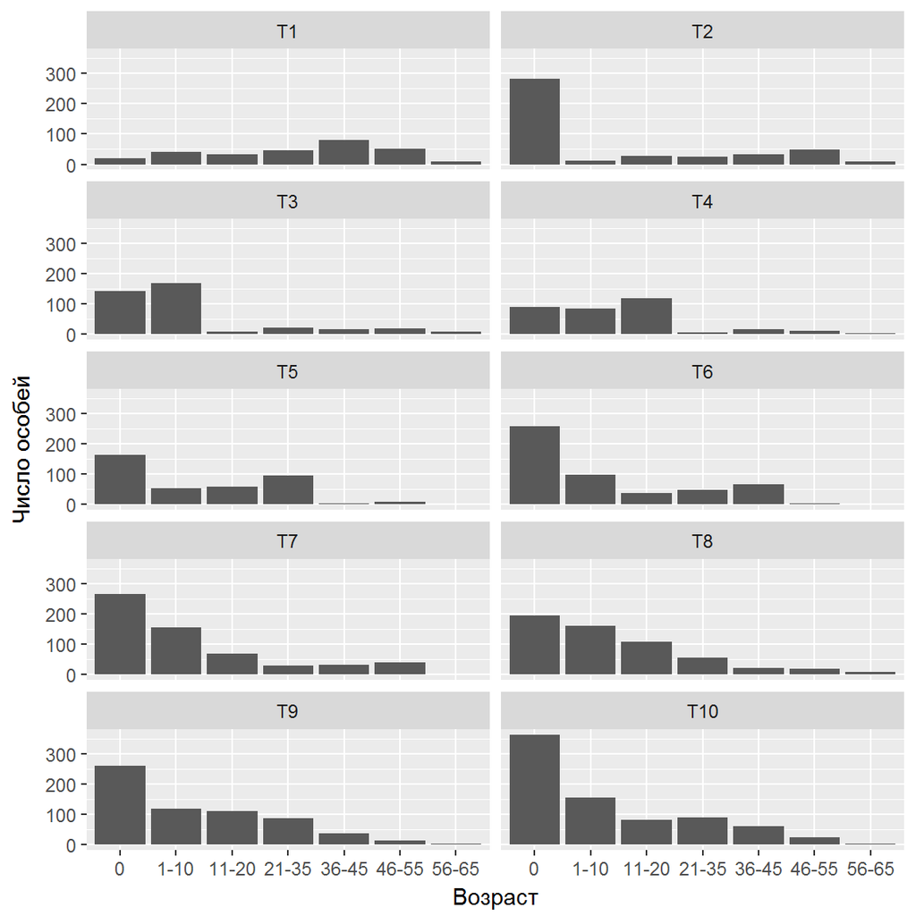

## Вычисление корреляций через произведение матриц

\[\bf{Cor} = \frac{\bf{{X}'_{stand}}\bf{X_{stand}}}{N-1}\]

Используем известные нам данные по размеру головного мозга

```r
brain <- read.csv("data/IQ_brain.csv", header = TRUE)
br <- brain[complete.cases(brain), -1]
br <- as.matrix(br)
br_scaled <- scale(br) #Стандартизуем значения

t(br_scaled) %*% br_scaled / (nrow(br_scaled) - 1)
```

```
##               FSIQ     VIQ      PIQ   Weight  Height MRINACount
## FSIQ        1.0000  0.9451  0.93443 -0.05148 -0.1184      0.334
## VIQ         0.9451  1.0000  0.77602 -0.07609 -0.1190      0.300
## PIQ         0.9344  0.7760  1.00000  0.00251 -0.0932      0.378
## Weight     -0.0515 -0.0761  0.00251  1.00000  0.6996      0.513
## Height     -0.1184 -0.1190 -0.09316  0.69961  1.0000      0.588
## MRINACount  0.3337  0.3003  0.37778  0.51338  0.5884      1.000
```

## Некоторые свойства произведения матриц

1. Если существует произведение матриц \(\textbf{BC}\), то не обязательно существует \(\textbf{CB}\)

```r
B <- matrix(1:24, ncol = 4)
C <- matrix(1:12, ncol = 3)

B %*% C
```

```
##      [,1] [,2] [,3]
## [1,]  130  290  450
## [2,]  140  316  492
## [3,]  150  342  534
## [4,]  160  368  576
## [5,]  170  394  618
## [6,]  180  420  660
```

HO!

```r
C %*% B
```

Такое произведение невозможно

## Некоторые свойства произведения матриц

1. Всегда существует такое произведение матриц \(\textbf{CС'}\) и \(\textbf{C'С}\)

```r
C %*% t(C)
```

```
##      [,1] [,2] [,3] [,4]
## [1,]  107  122  137  152
## [2,]  122  140  158  176
## [3,]  137  158  179  200
## [4,]  152  176  200  224
```

```r
t(C) %*% C
```

```
##      [,1] [,2] [,3]
## [1,]   30   70  110
## [2,]   70  174  278
## [3,]  110  278  446
```

## Некоторые свойства произведения матриц

1. Произведение матриц \(\textbf{BC}\) как правило не равно \(\textbf{CB}\)

```r
B <- matrix(1:9, ncol = 3)
C <- matrix(11:19, ncol = 3)

B %*%  C
```

```
##      [,1] [,2] [,3]
## [1,]  150  186  222
## [2,]  186  231  276
## [3,]  222  276  330
```

```r
C %*% B
```

```
##      [,1] [,2] [,3]
## [1,]   90  216  342
## [2,]   96  231  366
## [3,]  102  246  390
```

## Некоторые свойства произведения матриц

1. \([\textbf{BC}]' = \textbf{C}'\textbf{B}'\)

```r
t(B %*% C)
```

```
##      [,1] [,2] [,3]
## [1,]  150  186  222
## [2,]  186  231  276
## [3,]  222  276  330
```

```r
t(C) %*% t(B)
```

```
##      [,1] [,2] [,3]
## [1,]  150  186  222
## [2,]  186  231  276
## [3,]  222  276  330
```

## Некоторые свойства произведения матриц

1. Произведение \(\textbf{BB'}\) и \(\textbf{B'B}\) всегда дает симметричную матрицу

```r
B %*% t(B)
```

```
##      [,1] [,2] [,3]
## [1,]   66   78   90
## [2,]   78   93  108
## [3,]   90  108  126
```

```r
t(B) %*% B
```

```
##      [,1] [,2] [,3]
## [1,]   14   32   50
## [2,]   32   77  122
## [3,]   50  122  194
```

## Определитель матрицы

Определитель матрицы - это некоторое число.

По значению этого числа можно *определить* есть ли у матрицы некоторые свойства (например, обратима ли матрица).

Определитель бывает только у квадратных матриц.

Матрицы, имеющие определитель равный нулю, называются *сингулярными* матрицами.

```r
det(B)
```

```
## [1] 0
```

```r
BB <- t(B) %*% B
det(BB)
```

```
## [1] 0
```

## Обращение (инверсия) матриц

В матричной алгебре нет процедуры деления. Вместо нее используют обращение матриц.

\[ \textbf{X}^{-1}\textbf{X} = \textbf{I} \] Произведение инверсии матрицы и исходной матрицы дает единичную матрицу

## Обращение (инверсия) матриц

Только некоторые квадратные матрицы, могут иметь обратную матрицу.

Поэтому для квадратных матриц справедливо \(\textbf{X} \textbf{X}^{-1} = \textbf{X}^{-1} \textbf{X}\)

## Обращение (инверсия) матриц

Для матриц, определитель которых равен нулю, обратной матрицы не существует

## Решение в среде R

Создадим матрицу

```
##      [,1] [,2] [,3]
## [1,]    1    2    3
## [2,]    4    5    6
## [3,]    7    8   10
```

Ее определитель

```r
det(X)
```

```
## [1] -3
```

## Решение в среде R

Обратная матрица

```r
solve(X)
```

```
##        [,1]  [,2] [,3]
## [1,] -0.667 -1.33    1
## [2,] -0.667  3.67   -2
## [3,]  1.000 -2.00    1
```

По определению, \(\textbf{X}^{-1}\textbf{X} = \textbf{I}\)

```r
round(solve(X) %*% X )
```

```
##      [,1] [,2] [,3]
## [1,]    1    0    0
## [2,]    0    1    0
## [3,]    0    0    1
```

## Примнение обращенных матриц

## Решение систем линейных уравнений

Простейший случай использования обратных матриц - решение систем линейных уравнений \[ \begin{cases} 1x + 2y + 3z = 2\\ 4x + 5y + 6z = 4 \\ 7x + 8y + 10z = 10 \end{cases} \]

Эту систему можно представить в матричном виде

\[ \begin{pmatrix} 1 & 2 & 3 \\ 4 & 5 & 6 \\ 7 & 8 & 10 \end{pmatrix} \begin{pmatrix} x \\ y \\ z \end{pmatrix} = \begin{pmatrix} 2 \\ 4 \\ 10 \end{pmatrix} \]

Тогда

\[ \begin{pmatrix} x \\ y \\ z \end{pmatrix} = \begin{pmatrix} 1 & 2 & 3 \\ 4 & 5 & 6 \\ 7 & 8 & 10 \end{pmatrix} ^{-1} \begin{pmatrix} 2 \\ 4 \\ 10 \end{pmatrix} \]

## Задание

Решите приведенную систему уравнений с использованием матричной алгебры

\[ \begin{cases} 1x + 2y + 3z = 2\\ 4x + 5y + 6z = 4 \\ 7x + 8y + 10z = 10 \end{cases} \]

## Решение

```r
Coef <- matrix(c(1 , 2 , 3 ,
         4 , 5 , 6 ,
         7 , 8 , 10), byrow = T, ncol = 3)
Val <- c(2,4,10)

solve(Coef) %*% Val
```

```
##       [,1]
## [1,]  3.33
## [2,] -6.67
## [3,]  4.00
```

## Проверим

```r
round(1*3.33 + 2*-6.67 + 3*4.00)
```

```
## [1] 2
```

```r
round(4*3.33 + 5*-6.67 + 6*4.00)
```

```
## [1] 4
```

```r
round(7*3.33 + 8*-6.67 + 10*4.00)
```

```
## [1] 10
```

## Подбор параметров линейной регрессии методом наименьших квадратов с использованием матричной алгебры

## Линейная регрессия в матричном виде

При подборе коэффициентов методом наименьших квадратов нам надо решить следующее матричное уравнение:

\[ \textbf{y} = \textbf{X} \pmb{\beta} \]

Здесь

\(\textbf{y}\) - вектор предсказанных значений

\(\textbf{X}\) - модельная матрица \(\begin{pmatrix} 1 & x_1 \\ 1 & x_2 \\ \vdots & \vdots \\ 1 & x_n \end{pmatrix}\)

\(\pmb{\beta}\) - вектор коэффициентов модели \(b_0 + b_1x\)

## Решение этого уравнения

Умножим обе части уравнения на транспонированную матрицу \(\textbf{X}'\)

\[ \textbf{X}' \textbf{y} = \textbf{X}'\textbf{X} \pmb{\beta}\]

Матрица \(\textbf{X}'\textbf{X}\) - это всегда квадратная матрица. Ее можно обратить.

Тогда \[ \pmb{\beta} = [\textbf{X}'\textbf{X}]^{-1}[\textbf{X}'\textbf{y}] \]

## Подбираем коэффициенты с помощью фунции `lm()`

```r
data(cars)
Mod <- lm(dist ~ speed, data = cars)
summary(Mod)
```

```
##
## Call:
## lm(formula = dist ~ speed, data = cars)
##
## Residuals:
##    Min     1Q Median     3Q    Max
## -29.07  -9.53  -2.27   9.21  43.20
##
## Coefficients:
##             Estimate Std. Error t value Pr(>|t|)
## (Intercept)  -17.579      6.758   -2.60    0.012 *
## speed          3.932      0.416    9.46  1.5e-12 ***
## ---
## Signif. codes:  0 '***' 0.001 '**' 0.01 '*' 0.05 '.' 0.1 ' ' 1
##
## Residual standard error: 15.4 on 48 degrees of freedom
## Multiple R-squared:  0.651,  Adjusted R-squared:  0.644
## F-statistic: 89.6 on 1 and 48 DF,  p-value: 1.49e-12
```

## Коэффициенты модели

```r
coefficients(Mod)
```

```
## (Intercept)       speed
##      -17.58        3.93
```

## Графическое отражение, построенное с помощью `geom_smooth()`

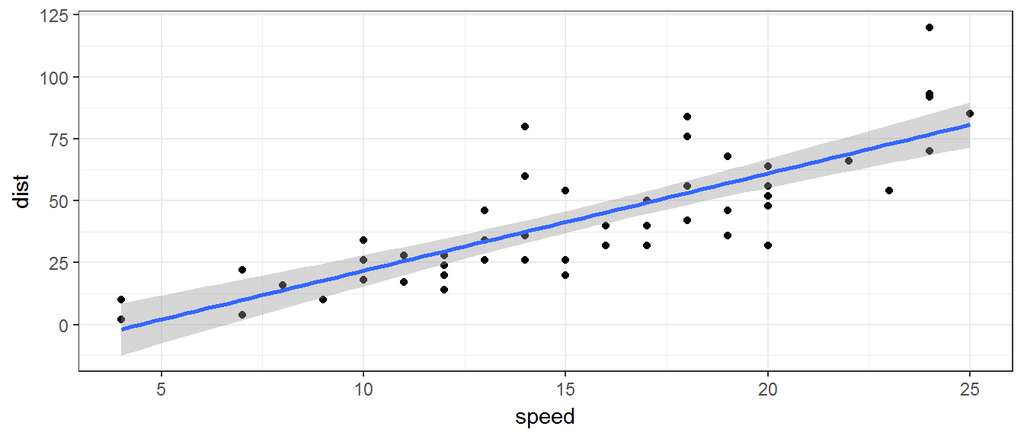

```r
library(ggplot2)
theme_set(theme_bw())
ggplot(cars, aes(x = speed, y = dist)) + geom_point() + geom_smooth(method = "lm")
```

## Вычисление коэффициентов линейной регрессии вручную

Находим вектор коэффициентов на основе уравнения \(\pmb{\beta} = [\textbf{X}'\textbf{X}]^{-1}[\textbf{X}'\textbf{y}]\)

```r
X <- model.matrix(~speed, data = cars)
Y <- cars$dist
betas <- solve(t(X) %*% X) %*% (t(X) %*% Y)
betas
```

```
##               [,1]
## (Intercept) -17.58
## speed         3.93
```

## Применение матричной алгебры для построения графиков регрессионных моделей

Шаг 1. Формируем искусственный датасет со всеми возможными значениями предиктора

```r
MyData <- data.frame(speed = seq(min(cars$speed), max(cars$speed)))
head(MyData)
```

```
##   speed
## 1     4
## 2     5
## 3     6
## 4     7
## 5     8
## 6     9
```

## Применение матричной алгебры для построения графиков регрессионных моделей

Шаг 2. Формируем модельную матрицу для искусственно созданных данных

```r
X2 <- model.matrix( ~ speed, data = MyData)
head(X2)
```

```
##   (Intercept) speed
## 1           1     4
## 2           1     5
## 3           1     6
## 4           1     7
## 5           1     8
## 6           1     9
```

## Применение матричной алгебры для построения графиков регрессионных моделей

Шаг 3. Вычисляем предсказанные значения для искусственно созданных данных

```r
MyData$Predicted <- X2 %*% betas
```

## Применение матричной алгебры для построения графиков регрессионных моделей

Шаг 4. Рисуем график

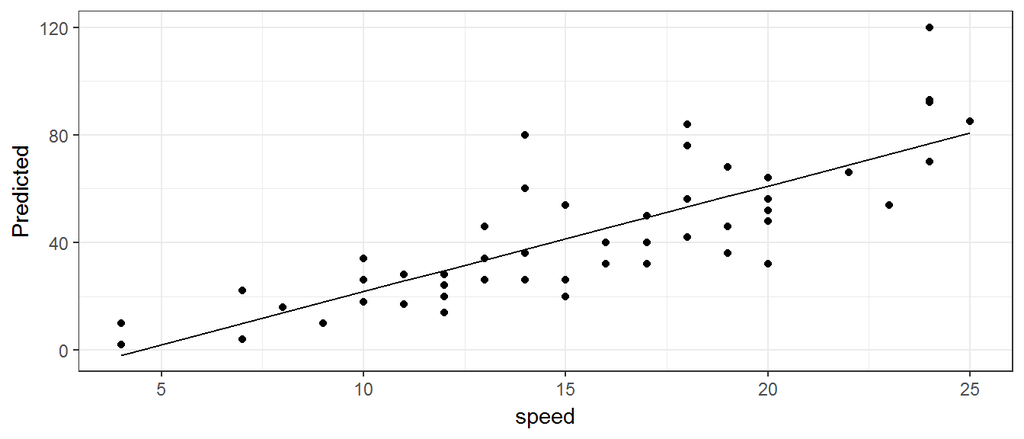

```r
library(ggplot2)
ggplot(MyData, aes(x = speed, y = Predicted)) + geom_line() + geom_point(data = cars, aes(x = speed, y = dist))
```

Осталось нанести границы доверительной области.

Для этого необходимо ввести понятие **вариационно-ковариационной матрицы**

## Вычисление вариационно-ковариационной матрицы

Подобранные параметры (вектор коэффициентов)- это лишь *оценки* некоторых параметров, описывающих связь между зависимой переменной и предиктором в генеральной совокупности.

Варьирование параметров описывает *вриацонно-ковариационная матрица*.

В среде `R`, если модель задана, например, с помощью функции `lm()`, эта матрица вычисляется так

```r
vcov(Mod)
```

```
##             (Intercept)  speed
## (Intercept)       45.68 -2.659
## speed             -2.66  0.173
```

## Вычисление вариационо-ковариационной матрицы вручную

\[ \textbf{V}(\pmb{\beta}) = s^2[\textbf{X}'\textbf{X}]^{-1} \] где

\[ s^2 = \frac{\sum\limits_{\substack{i=1}}^n e_i^2}{n-k} \]

\(\sum\limits_{\substack{i=1}}^n e_i^2\) - сумма квадратов остатков  
\(n\) - объем выборки  
\(k\) - число параметров в модели

## Вычисление вариационо-ковариационной матрицы вручную

Вычисляем \(\sum\limits_{\substack{i=1}}^n e_i^2\)

```r
predict_values <- X %*% betas

resid_values <- cars$dist - predict_values

s2 <- sum(resid_values^2)/(length(resid_values) - length(betas))

s2
```

```
## [1] 237
```

Видели ли мы это число в `summary(Mod)`? >- ДА! это квадрат `Residual standard error: 15.4 on 48 degrees of freedom`

## Вычисление вариационо-ковариационной матрицы вручную

Вычисляем вариационно-ковариационную матрицу

\[ \textbf{V}(\pmb{\beta}) = s^2[\textbf{X}'\textbf{X}]^{-1} \]

```r
covbetas <- s2 * solve(t(X) %*% X)
covbetas
```

```
##             (Intercept)  speed
## (Intercept)       45.68 -2.659
## speed             -2.66  0.173
```

## Применение матричной алгебры для построения графиков регрессионных моделей

Шаг 5. Вычисляем границы доверительных интервалов

```r
# Вычисляем стандартные отшибки путем перемножения матриц
  MyData$se <- sqrt(diag(X2 %*% covbetas %*% t(X2)))

# Вычисляем доверительные интервалы
MyData$CiUp  <- MyData$Predicted + 1.96 *MyData$se

MyData$CiLow  <- MyData$Predicted - 1.96 *MyData$se
```

## Применение матричной алгебры для построения графиков регрессионных моделей

Шаг 6. Строим график

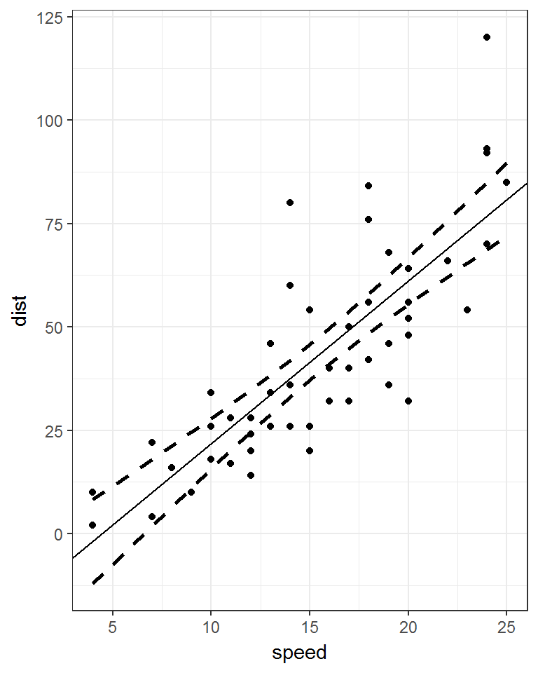

```r
ggplot(MyData, aes(x = speed, y = predicted)) +
  geom_line(aes(x = speed, y = CiUp),
            linetype = 2, size = 1) +
  geom_line(aes(x = speed, y = CiLow),
            linetype = 2, size = 1)+
  geom_abline(slope = betas[2], intercept = betas[1]) +
  geom_point(data = cars, aes(x = speed, y = dist)) +
  ylab("dist")
```

## Сравним результаты

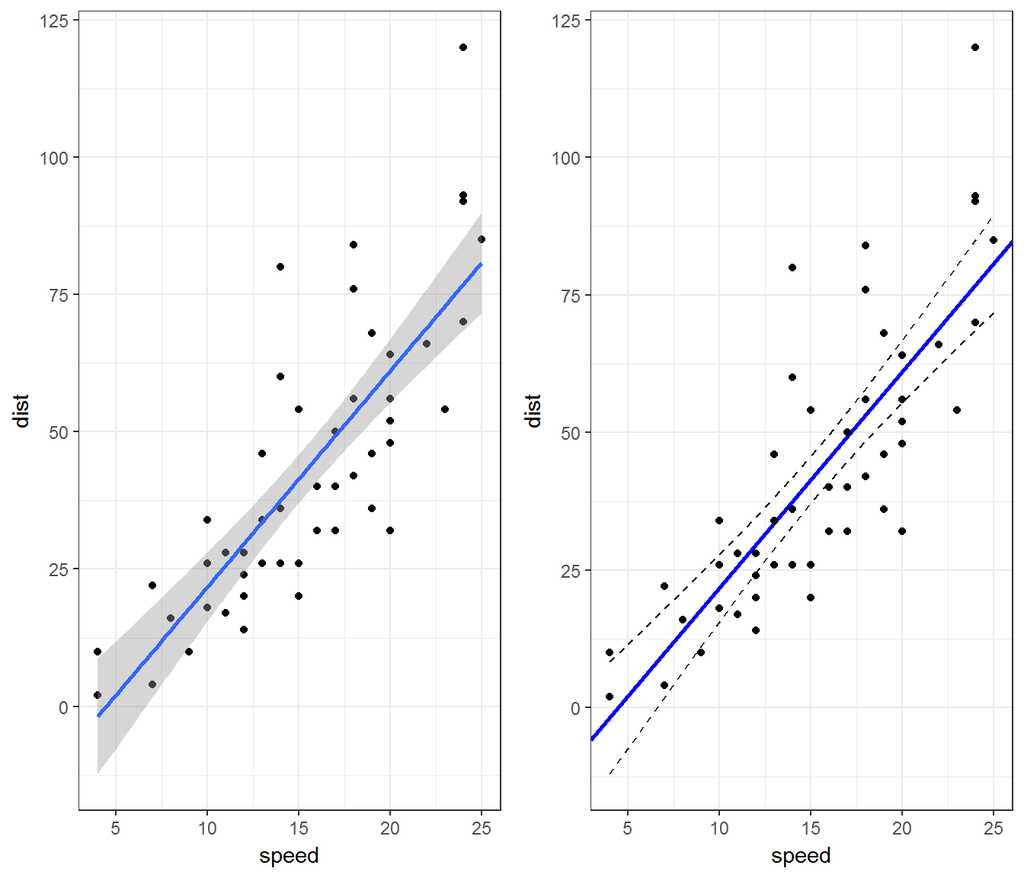

## Not The End

[figure not shown]

## Что почитать

- Legendre P., Legendre L. (2012) Numerical ecology. Second english edition. Elsevier, Amsterdam. Глава 2. Matrix algebra: a summary.